# Prediction of Exercise Quality

# Training and Validation Data

I first split the (training) data into two parts in the following manner:

```r
library(caret)
data <- read.csv("./pml-training.csv", na.strings=c("NA", "", "#DIV/0!"))
set.seed(123)
inTrain <- createDataPartition(data$classe, p=0.6, list=F)
training  <- data[inTrain, ]
testing  <- data[-inTrain, ]
```

The data stored in variable *triaining* is used to fit models and the data stored in variable *testing* is set aside for validation.

# Feature Selection

In selecting features, I removed several of the features and augmented them with the k-nearest-neighbor imputation. In the following subsection, I describe how I performed them.

## Feature Removal

I removed the following features since all of their values are NA (e.g., empty strings or error message for “division by zero”):

- kurtosis_yaw_belt
- skewness_yaw_belt
- kurtosis_yaw_dumbbell
- skewness_yaw_dumbbell
- kurtosis_yaw_forearm
- skewness_yaw_forearm

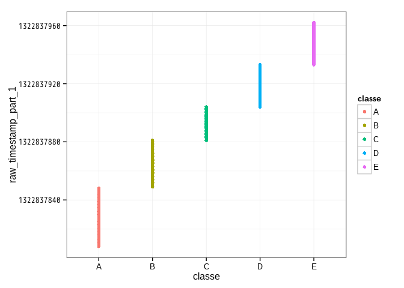

Figure: Plot of raw_timestamp_part_1 vs. classe.

## Feature Imputation

The authors of the paper(Velloso et al. 2013) reported in the section of feature selection: *“17 features were selected: in the belt, were selected the mean and variance of the roll, maximum, range and variance of the accelerometer vector, variance of the gyro and variance of the magnetometer.”*

To utilize this information, I decieded to impute the average and variance of features based on existing values. After extracting columns that are not a factor, I applied k-nearest-neighbor imputation using caret package with default parameters.

# Result

```
## Confusion Matrix and Statistics
##
##           Reference
## Prediction    A    B    C    D    E
##          A 2225   14    2    0    0
##          B    7 1501   20    0    0
##          C    0    3 1336   21    7
##          D    0    0   10 1265    4
##          E    0    0    0    0 1431
##
## Overall Statistics
##
##                Accuracy : 0.9888
##                  95% CI : (0.9862, 0.991)
##     No Information Rate : 0.2845
##     P-Value [Acc > NIR] : < 2.2e-16
##
##                   Kappa : 0.9858
##  Mcnemar's Test P-Value : NA
##
## Statistics by Class:
##
##                      Class: A Class: B Class: C Class: D Class: E
## Sensitivity            0.9969   0.9888   0.9766   0.9837   0.9924
## Specificity            0.9971   0.9957   0.9952   0.9979   1.0000
## Pos Pred Value         0.9929   0.9823   0.9773   0.9891   1.0000
## Neg Pred Value         0.9988   0.9973   0.9951   0.9968   0.9983
## Prevalence             0.2845   0.1935   0.1744   0.1639   0.1838
## Detection Rate         0.2836   0.1913   0.1703   0.1612   0.1824
## Detection Prevalence   0.2856   0.1947   0.1742   0.1630   0.1824
## Balanced Accuracy      0.9970   0.9923   0.9859   0.9908   0.9962
```

The following table shows variable importance of my model:

```
## rf variable importance
##
##   only 20 most important variables shown (out of 149)
##
##                      Overall
## roll_belt            100.000
## pitch_forearm         49.103
## yaw_belt              48.492
## roll_forearm          40.080
## magnet_dumbbell_z     39.918
## magnet_dumbbell_y     37.439
## pitch_belt            36.920
## magnet_dumbbell_x     21.874
## accel_dumbbell_y      16.562
## roll_dumbbell         15.007
## magnet_belt_y         14.688
## accel_belt_z          14.394
## magnet_belt_z         14.060
## avg_roll_dumbbell     12.885
## accel_dumbbell_z      12.800
## accel_forearm_x       12.562
## yaw_arm               11.574
## total_accel_dumbbell  11.567
## magnet_forearm_z      10.671
## gyros_belt_z           9.952
```

Since the dataset for validation is relatively large, the estimate of accuracy (given by predicting on the validation set) has low bias and thus I expect the model would perform well on unknown datasets.

The following ways can be taken to improve my model further:

- use principal component analysis to reduce correlation between variables (e.g., rotation of forearm and that of dumbbell) and apply some other model
- combine the other models through voting

References

Velloso, Eduardo, Andreas Bulling, Hans Gellersen, Wallace Ugulino, and Hugo Fuks. 2013. “Qualitative Activity Recognition of Weight Lifting Exercises.” http://groupware.les.inf.puc-rio.br/public/papers/2013.Velloso.QAR-WLE.pdf.

“Weight Lifting Exercises Dataset.” http://groupware.les.inf.puc-rio.br/har.